# Lab 16- Visualizing NEON Data

Joy Tumusiime

2024-05-01

# 1 Motivating Factors

The motivating factors for this experiment was to analyze the diversity of taxonomic groups at the Guanica Forest site. Knowing the diversity of taxonomic groups can allow researchers to understand what species can grow in certain areas around the world depending on the geography of the area. Additionally, analyzing the sites in which Dormibacterota was found allows researchers to understand where this certain type of species prefers to live in or thrives in.

# 2 Introduction

The Guanica Dry Forest Reserve (GUAN) is a terrestrial NEON field site located in a subtropical dry zone along the southern coast of Puerto Rico. Plant species along the reserve include cacti, grasses, and shrubs and the forest has of areas with semi-evergreen, deciduous and scrub trees. Site has a warm climate with low annual rainfall averaging 840 mm (33 in.) and an average annual temperature of 23°C (73°F). [@noauthor_guanica_nodate] https://www.neonscience.org/field-sites/guan

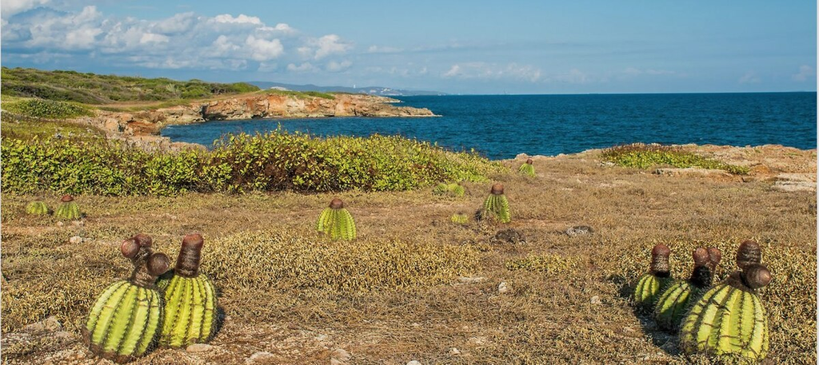

Guanica Dry Forest Reserve

```r
if (!require("BiocManager", quietly = TRUE))
    install.packages("BiocManager")
BiocManager::install("treeio")
BiocManager::install("ggtreeExtra")
library(tidyverse)
library(knitr)
library(ggtree)
```

```r
library(TDbook) #A Companion Package for the Book "Data Integration, Manipulation and Visualization of Phylogenetic Trees" by Guangchuang Yu (2022, ISBN:9781032233574).
library(ggimage)
library(rphylopic)
library(treeio)
library(tidytree)
library(ape)
library(TreeTools)
library(phytools)
library(ggnewscale)
library(ggtreeExtra)
library(ggstar)
library(DT)
```

```r
NEON_MAGs <- read_csv("data/NEON/GOLD_Study_ID_Gs0161344_NEON_edArchaea.csv") %>%
  # remove columns that are not needed for data analysis
  select(-c(`GOLD Study ID`, `Bin Methods`, `Created By`, `Date Added`)) %>%
  # create a new column with the Assembly Type
  mutate("Assembly Type" = case_when(`Genome Name` == "NEON combined assembly" ~ `Genome Name`,
                            TRUE ~ "Individual")) %>%
  mutate_at("Assembly Type", str_replace, "NEON combined assembly", "Combined") %>%
  separate(`GTDB-Tk Taxonomy Lineage`, c("Domain", "Phylum", "Class", "Order", "Family", "Genus"), "; ", remove = FALSE) %>%
  # Get rid of the the common string "Soil microbial communities from "
  mutate_at("Genome Name", str_replace, "Terrestrial soil microbial communities from ", "") %>%
  # Use the first `-` to split the column in two
  separate(`Genome Name`, c("Site","Sample Name"), " - ") %>%
  # Get rid of the the common string "S-comp-1"
  mutate_at("Sample Name", str_replace, "-comp-1", "") %>%
  # separate the Sample Name into Site ID and plot info
  separate(`Sample Name`, c("Site ID","subplot.layer.date"), "_", remove = FALSE,) %>%
  # separate the plot info into 3 columns
  separate(`subplot.layer.date`, c("Subplot", "Layer", "Date"), "-")
NEON_MAGs <- read_csv("data/NEON/GOLD_Study_ID_Gs0161344_NEON_2024_4_21.csv") %>%
  # remove columns that are not needed for data analysis
  select(-c(`GOLD Study ID`, `Bin Methods`, `Created By`, `Date Added`, `Bin Lineage`)) %>%
  # create a new column with the Assembly Type
  mutate("Assembly Type" = case_when(`Genome Name` == "NEON combined assembly" ~ `Genome Name`,
                            TRUE ~ "Individual")) %>%
  mutate_at("Assembly Type", str_replace, "NEON combined assembly", "Combined") %>%
  mutate_at("GTDB-Tk Taxonomy Lineage", str_replace, "d__", "") %>%
  mutate_at("GTDB-Tk Taxonomy Lineage", str_replace, "p__", "") %>%
  mutate_at("GTDB-Tk Taxonomy Lineage", str_replace, "c__", "") %>%
  mutate_at("GTDB-Tk Taxonomy Lineage", str_replace, "o__", "") %>%
  mutate_at("GTDB-Tk Taxonomy Lineage", str_replace, "f__", "") %>%
  mutate_at("GTDB-Tk Taxonomy Lineage", str_replace, "g__", "") %>%
  mutate_at("GTDB-Tk Taxonomy Lineage", str_replace, "s__", "") %>%
  separate(`GTDB-Tk Taxonomy Lineage`, c("Domain", "Phylum", "Class", "Order", "Family", "Genus", "Species"), ";", remove = FALSE) %>%
  mutate_at("Domain", na_if,"") %>%
  mutate_at("Phylum", na_if,"") %>%
  mutate_at("Class", na_if,"") %>%
  mutate_at("Order", na_if,"") %>%
  mutate_at("Family", na_if,"") %>%
  mutate_at("Genus", na_if,"") %>%
  mutate_at("Species", na_if,"") %>%

  # Get rid of the the common string "Soil microbial communities from "
  mutate_at("Genome Name", str_replace, "Terrestrial soil microbial communities from ", "") %>%
  # Use the first `-` to split the column in two
  separate(`Genome Name`, c("Site","Sample Name"), " - ") %>%
  # Get rid of the the common string "S-comp-1"
  mutate_at("Sample Name", str_replace, "-comp-1", "") %>%
  # separate the Sample Name into Site ID and plot info
  separate(`Sample Name`, c("Site ID","subplot.layer.date"), "_", remove = FALSE,) %>%
  # separate the plot info into 3 columns
  separate(`subplot.layer.date`, c("Subplot", "Layer", "Date"), "-")
NEON_metagenomes <- read_tsv("data/NEON/exported_img_data_Gs0161344_NEON.tsv") %>%
  select(-c(`Domain`, `Sequencing Status`, `Sequencing Center`)) %>%
  rename(`Genome Name` = `Genome Name / Sample Name`) %>%
  filter(str_detect(`Genome Name`, 're-annotation', negate = T)) %>%
  filter(str_detect(`Genome Name`, 'WREF plot', negate = T))
NEON_metagenomes <- NEON_metagenomes %>%
  # Get rid of the the common string "Soil microbial communities from "
  mutate_at("Genome Name", str_replace, "Terrestrial soil microbial communities from ", "") %>%
  # Use the first `-` to split the column in two
  separate(`Genome Name`, c("Site","Sample Name"), " - ") %>%
  # Get rid of the the common string "-comp-1"
  mutate_at("Sample Name", str_replace, "-comp-1", "") %>%
  # separate the Sample Name into Site ID and plot info
  separate(`Sample Name`, c("Site ID","subplot.layer.date"), "_", remove = FALSE,) %>%
  # separate the plot info into 3 columns
  separate(`subplot.layer.date`, c("Subplot", "Layer", "Date"), "-")
NEON_chemistry <- read_tsv("data/NEON/neon_plot_soilChem1_metadata.tsv") %>%
  # remove -COMP from genomicsSampleID
  mutate_at("genomicsSampleID", str_replace, "-COMP", "")
NEON_MAGs_metagenomes_chemistry <- NEON_MAGs %>%
  left_join(NEON_metagenomes, by = "Sample Name") %>%
  left_join(NEON_chemistry, by = c("Sample Name" = "genomicsSampleID")) %>%
  rename("label" = "Bin ID")
```

```r
tree_arc <- read.tree("data/NEON/gtdbtk.ar53.decorated.tree")
tree_bac <- read.tree("data/NEON/gtdbtk.bac120.decorated.tree")
```

```r
# Make a vector with the internal node labels
node_vector_bac = c(tree_bac$tip.label,tree_bac$node.label)

# Search for your Phylum or Class to get the node
grep("Dormibacterota", node_vector_bac, value = TRUE)
```

```
## [1] "'1.0:p__Dormibacterota; c__Dormibacteria'"
```

```r
match(grep("Dormibacterota", node_vector_bac, value = TRUE), node_vector_bac)
```

```
## [1] 1767
```

```r
# First need to preorder tree before extracting. N
tree_bac_preorder <- Preorder(tree_bac)
tree_Dormibacterota <- Subtree(tree_bac_preorder, 1767)
```

```r
NEON_MAGs_Dormibacterota <- NEON_MAGs_metagenomes_chemistry %>%
  filter(Phylum == "Dormibacterota")
```

# 3 Results

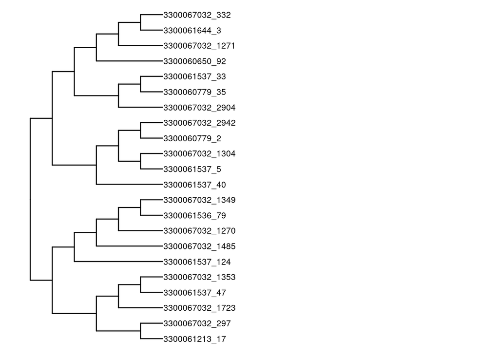

```r
ggtree(tree_Dormibacterota) +
  geom_tiplab(size=3) +
  xlim(0,20)
```

## Basic Circular

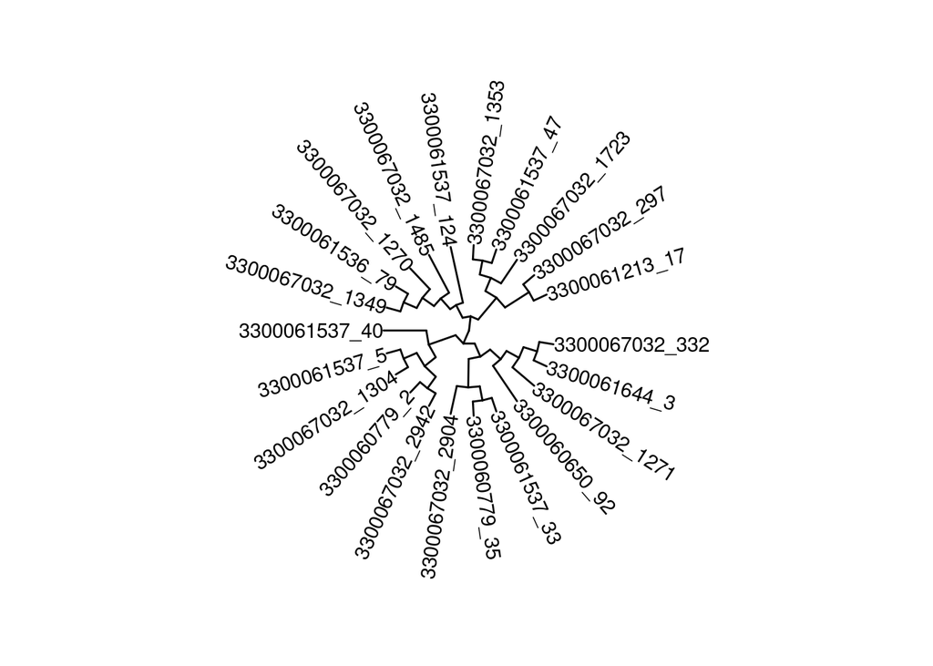

```r
ggtree(tree_Dormibacterota, layout="circular") +
  geom_tiplab(aes(angle=angle))+
    theme_tree() +
    xlim(0,18)
```

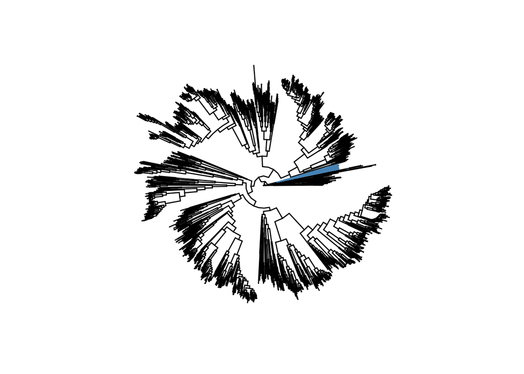

```r
ggtree(tree_bac, layout="circular") +
    geom_hilight(node=1767, fill="steelblue", alpha=10)
```

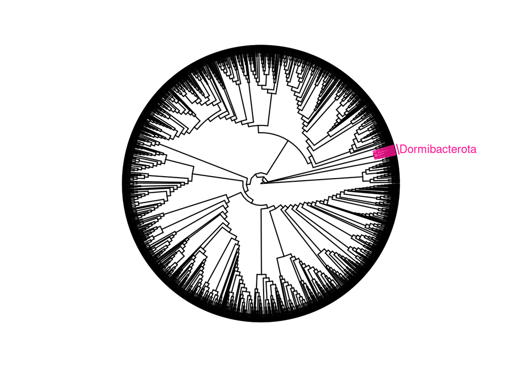

```r
ggtree(tree_bac, layout="circular", branch.length="none") +
    geom_hilight(node=1767, fill="deeppink1", alpha=.8) +
    geom_cladelab(node=1767, label="Dormibacterota", align=TRUE,
                  offset = 0, textcolor='deeppink1', barcolor='deeppink1')
```

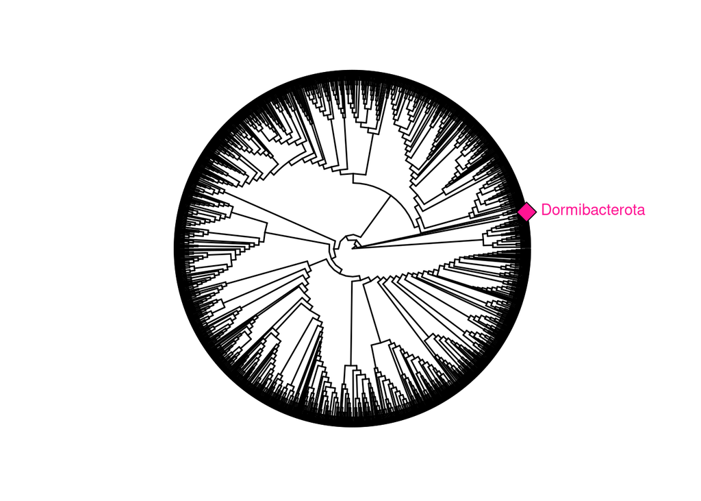

```r
ggtree(tree_bac, layout="circular", branch.length="none") %>%
  collapse(node=1767) +
  geom_point2(aes(subset=(node==55)), shape=23, size=5, fill='deeppink1') +
  geom_cladelab(node=55, label="Dormibacterota", align=TRUE,
                  offset = 2, textcolor='deeppink1')
```

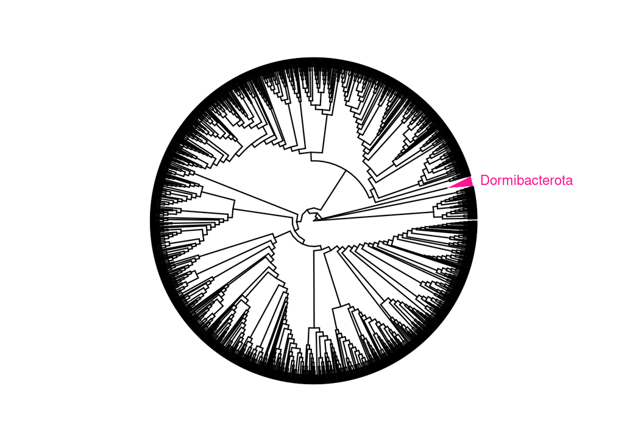

```r
p <- ggtree(tree_bac, layout="circular", branch.length="none")
scaleClade(p, 1767, .8) %>% collapse(1767, 'min', fill="deeppink1")  +
  geom_cladelab(node=1767, label="Dormibacterota", align=TRUE,
                  offset = 0.8, textcolor='deeppink1')
```

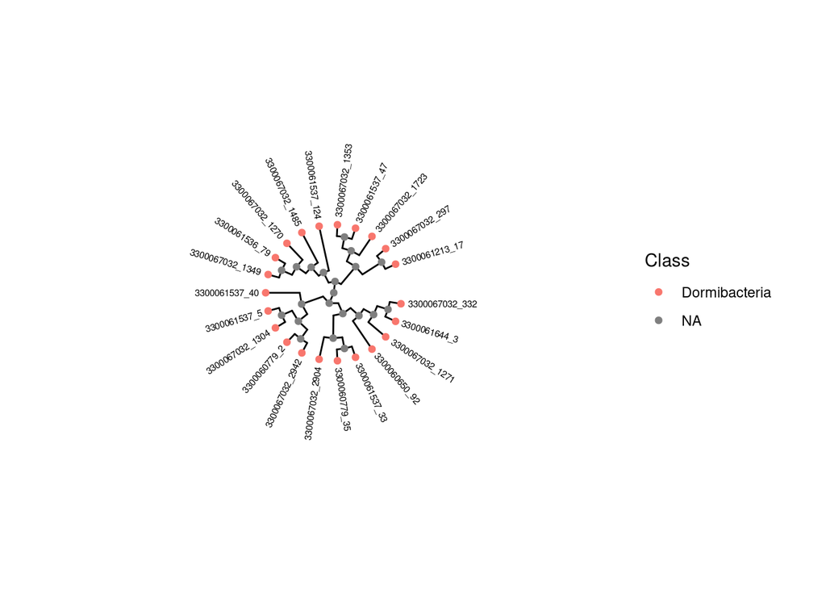

```r
ggtree(tree_Dormibacterota, layout="circular")  %<+%
  NEON_MAGs_metagenomes_chemistry +
  geom_tiplab(size=2, hjust=-.1) +
  xlim(0,20) +
  geom_point(mapping=aes(color=Class))
```

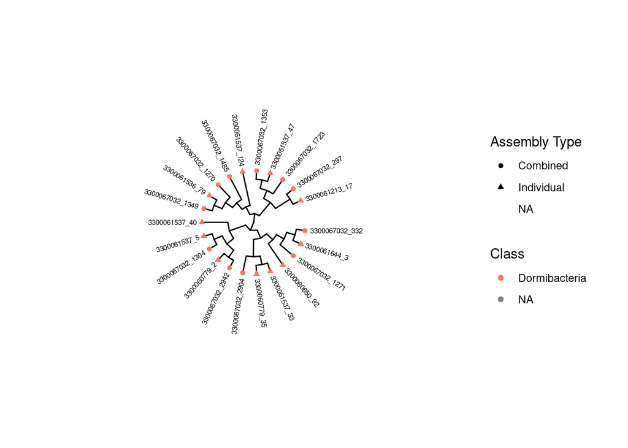

```r
ggtree(tree_Dormibacterota, layout="circular")  %<+%
  NEON_MAGs_metagenomes_chemistry +
  geom_tiplab(size=2, hjust=-.1) +
  xlim(0,20) +
  geom_point(mapping=aes(color=Class, shape = `Assembly Type`))
```

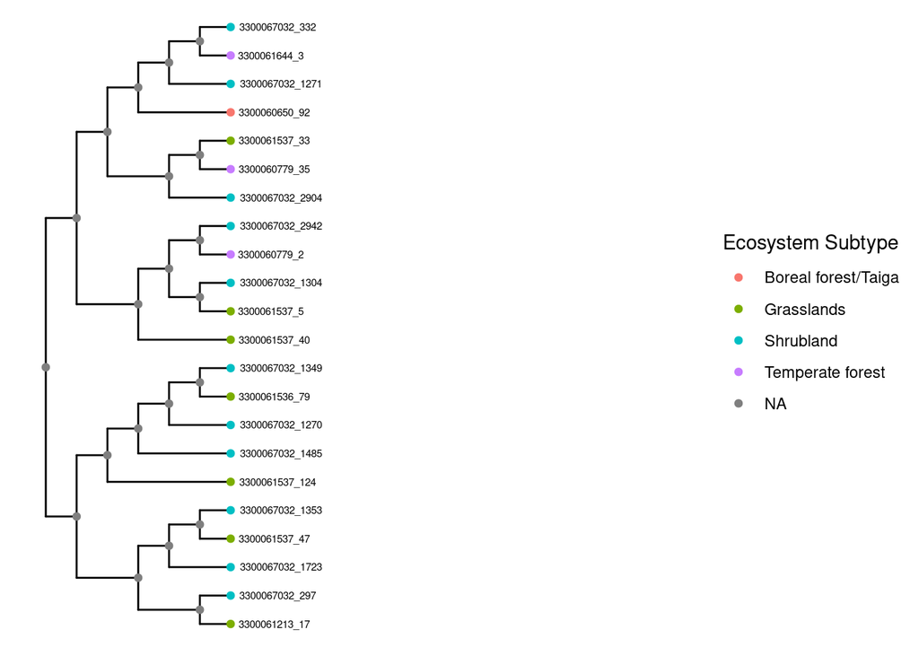

```r
ggtree(tree_Dormibacterota)  %<+%
  NEON_MAGs_metagenomes_chemistry +
  geom_tiplab(size=2, hjust=-.1) +
  xlim(0,20) +
  geom_point(mapping=aes(color=`Ecosystem Subtype`))
```

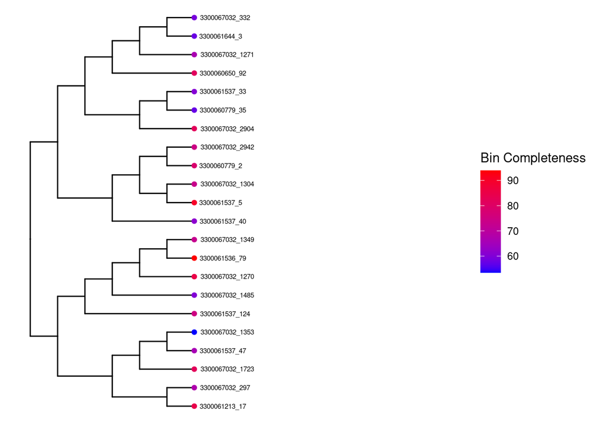

```r
ggtree(tree_Dormibacterota)  %<+%
  NEON_MAGs_metagenomes_chemistry +
  geom_tippoint(aes(colour=`Bin Completeness`)) +
  scale_colour_gradient(low='blue', high='red') +
  geom_tiplab(size=2, hjust=-.1) +
  xlim(0,15)
```

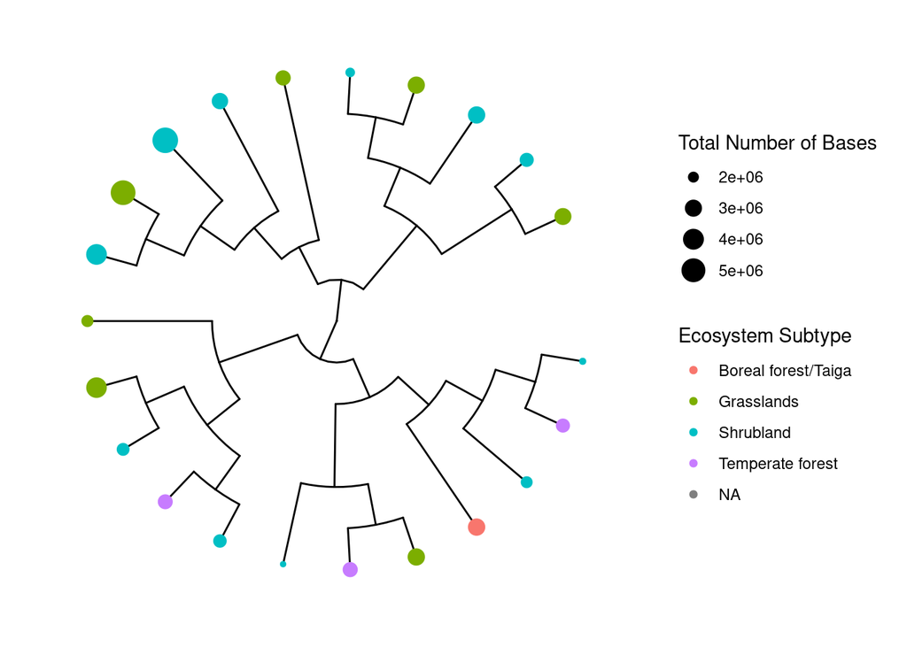

```r
ggtree(tree_Dormibacterota, layout="circular")  %<+%
  NEON_MAGs_metagenomes_chemistry +
  geom_point2(mapping=aes(color=`Ecosystem Subtype`, size=`Total Number of Bases`))
```

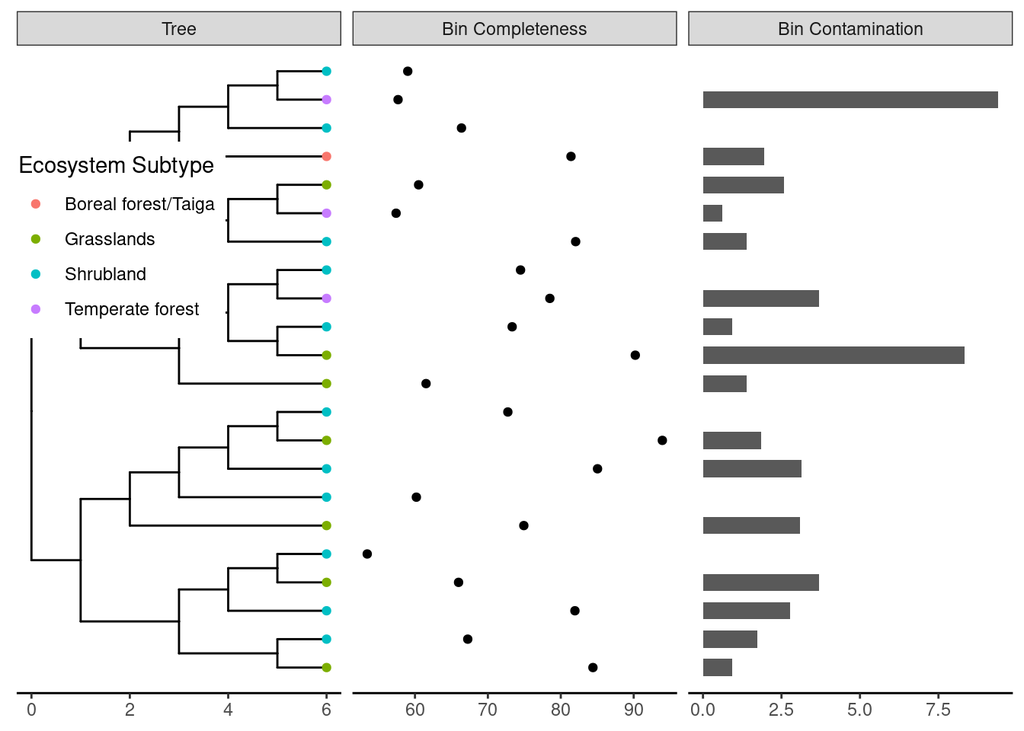

```r
# For unknown reasons the following does not like blank spaces in the names
NEON_MAGs_metagenomes_chemistry_noblank <- NEON_MAGs_metagenomes_chemistry %>%
  rename("AssemblyType" = "Assembly Type") %>%
  rename("BinCompleteness" = "Bin Completeness") %>%
  rename("BinContamination" = "Bin Contamination") %>%
  rename("TotalNumberofBases" = "Total Number of Bases") %>%
  rename("EcosystemSubtype" = "Ecosystem Subtype")

ggtree(tree_Dormibacterota)  %<+%
  NEON_MAGs_metagenomes_chemistry +
  geom_tippoint(aes(colour=`Ecosystem Subtype`)) +

# For unknown reasons the following does not like blank spaces in the names
  geom_facet(panel = "Bin Completeness", data = NEON_MAGs_metagenomes_chemistry_noblank, geom = geom_point,
      mapping=aes(x = BinCompleteness)) +
  geom_facet(panel = "Bin Contamination", data = NEON_MAGs_metagenomes_chemistry_noblank, geom = geom_col,
                aes(x = BinContamination), orientation = 'y', width = .6) +
  theme_tree2(legend.position=c(.1, .7))
```

```
## ! The following column names/name: Site.x, Sample Name, Site ID.x, Subplot.x, Layer.x, Date.x, IMG Genome ID.x, Bin Quality, GTDB-Tk Taxonomy Lineage, Domain, Phylum, Class, Order, Family, Genus, Species, 5s rRNA, 16s rRNA, 23s rRNA, tRNA Genes, Gene Count, Scaffold Count, taxon_oid, Study Name, …
```

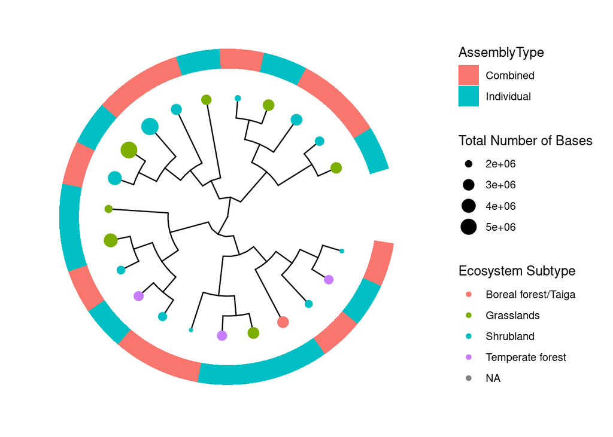

```r
ggtree(tree_Dormibacterota, layout="circular", branch.length="none") %<+%
  NEON_MAGs_metagenomes_chemistry +
  geom_point2(mapping=aes(color=`Ecosystem Subtype`, size=`Total Number of Bases`)) +
  new_scale_fill() +
  geom_fruit(
      data=NEON_MAGs_metagenomes_chemistry_noblank,
      geom=geom_tile,
      mapping=aes(y=label, x=1, fill= AssemblyType),
      offset=0.08,   # The distance between external layers, default is 0.03 times of x range of tree.
      pwidth=0.25 # width of the external layer, default is 0.2 times of x range of tree.
      )
```

```
## ! The following column names/name: Site.x, Sample Name, Site ID.x, Subplot.x, Layer.x, Date.x, IMG Genome ID.x, Bin Quality, GTDB-Tk Taxonomy Lineage, Domain, Phylum, Class, Order, Family, Genus, Species, 5s rRNA, 16s rRNA, 23s rRNA, tRNA Genes, Gene Count, Scaffold Count, taxon_oid, Study Name, …
```

```
## ! The following column names/name: Site.x, Sample Name, Site ID.x, Subplot.x, Layer.x, Date.x, IMG Genome ID.x, Bin Quality, GTDB-Tk Taxonomy Lineage, Domain, Phylum, Class, Order, Family, Genus, Species, 5s rRNA, 16s rRNA, 23s rRNA, tRNA Genes, Gene Count, Scaffold Count, taxon_oid, Study Name, …
```

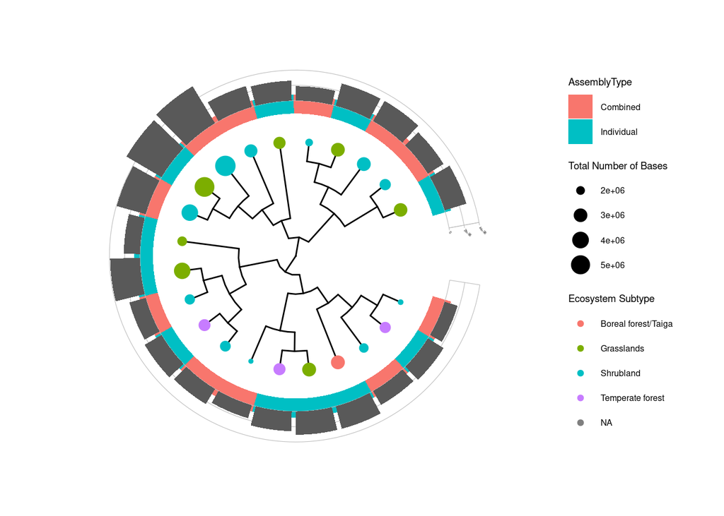

```r
ggtree(tree_Dormibacterota, layout="circular", branch.length="none") %<+%
  NEON_MAGs_metagenomes_chemistry +
  geom_point2(mapping=aes(color=`Ecosystem Subtype`, size=`Total Number of Bases`)) +
  new_scale_fill() +
  geom_fruit(
      data=NEON_MAGs_metagenomes_chemistry_noblank,
      geom=geom_tile,
      mapping=aes(y=label, x=1, fill= AssemblyType),
      offset=0.08,   # The distance between external layers, default is 0.03 times of x range of tree.
      pwidth=0.25 # width of the external layer, default is 0.2 times of x range of tree.
      ) +
  new_scale_fill() +
  geom_fruit(
          data=NEON_MAGs_metagenomes_chemistry_noblank,
          geom=geom_col,
          mapping=aes(y=label, x=TotalNumberofBases),
          pwidth=0.4,
          axis.params=list(
                          axis="x", # add axis text of the layer.
                          text.angle=-45, # the text size of axis.
                          hjust=0  # adjust the horizontal position of text of axis.
                      ),
          grid.params=list() # add the grid line of the external bar plot.
      ) +
      theme(#legend.position=c(0.96, 0.5), # the position of legend.
          legend.background=element_rect(fill=NA), # the background of legend.
          legend.title=element_text(size=7), # the title size of legend.
          legend.text=element_text(size=6), # the text size of legend.
          legend.spacing.y = unit(0.02, "cm")  # the distance of legends (y orientation).
      )
```

### Making a tree of your site

```r
NEON_MAGs_metagenomes_chemistry_GUAN <- NEON_MAGs_metagenomes_chemistry %>%
  filter(`Site ID.x` == "GUAN")
```

```r
NEON_MAGs_metagenomes_chemistry_GUAN <- NEON_MAGs_metagenomes_chemistry %>%
  filter(`Site ID.x` == "GUAN") %>%
  filter(Domain == "Archea")
```

```r
GUAN_MAGs_label <- NEON_MAGs_metagenomes_chemistry_GUAN$label
```

```r
tree_arc_GUAN_MAGs <-drop.tip(tree_arc,tree_arc$tip.label[-match(GUAN_MAGs_label, tree_arc$tip.label)])
```

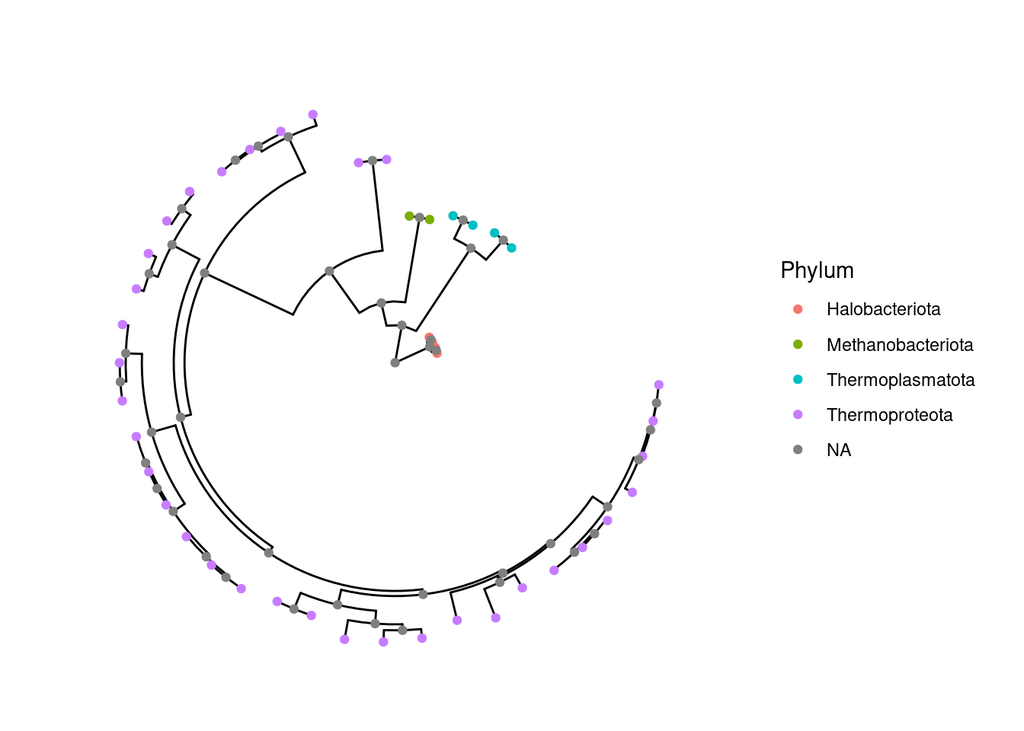

```r
ggtree(tree_arc_GUAN_MAGs, layout="circular")  %<+%
  NEON_MAGs_metagenomes_chemistry +
  geom_point(mapping=aes(color=Phylum))
```

```r
datatable(
NEON_MAGs %>%
  filter(str_detect(`Site`, 'Guanica State Forest and Biosphere Reserve, Puerto Rico'))
)
```

|  | Bin ID | Site | Sample Name | Site ID | Subplot | Layer | Date | IMG Genome ID | Bin Quality | GTDB-Tk Taxonomy Lineage | Domain | Phylum | Class | Order | Family | Genus | Species | Bin Completeness | Bin Contamination | Total Number of Bases | 5s rRNA | 16s rRNA | 23s rRNA | tRNA Genes | Gene Count | Scaffold Count | Assembly Type |
| --- | --- | --- | --- | --- | --- | --- | --- | --- | --- | --- | --- | --- | --- | --- | --- | --- | --- | --- | --- | --- | --- | --- | --- | --- | --- | --- | --- |
| 1 | 3300060854_24 | Guanica State Forest and Biosphere Reserve, Puerto Rico | GUAN_007-M-20210922 | GUAN | 007 | M | 20210922 | 3300060854 | MQ | Archaea;Thermoproteota;Nitrososphaeria;Nitrososphaerales;Nitrososphaeraceae;TH5896; | Archaea | Thermoproteota | Nitrososphaeria | Nitrososphaerales | Nitrososphaeraceae | TH5896 |  | 56.15 | 0.97 | 1533081 | 1 | 0 | 0 | 25 | 1741 | 146 | Individual |
| 2 | 3300060854_34 | Guanica State Forest and Biosphere Reserve, Puerto Rico | GUAN_007-M-20210922 | GUAN | 007 | M | 20210922 | 3300060854 | MQ | Archaea;Thermoproteota;Nitrososphaeria;Nitrososphaerales;Nitrososphaeraceae;JAJNBK01; | Archaea | Thermoproteota | Nitrososphaeria | Nitrososphaerales | Nitrososphaeraceae | JAJNBK01 |  | 53.25 | 1.46 | 1450069 | 0 | 0 | 0 | 30 | 1647 | 219 | Individual |
| 3 | 3300060854_37 | Guanica State Forest and Biosphere Reserve, Puerto Rico | GUAN_007-M-20210922 | GUAN | 007 | M | 20210922 | 3300060854 | MQ | Archaea;Thermoproteota;Nitrososphaeria;Nitrososphaerales;Nitrososphaeraceae;Nitrososphaera; | Archaea | Thermoproteota | Nitrososphaeria | Nitrososphaerales | Nitrososphaeraceae | Nitrososphaera |  | 53.24 | 0 | 789887 | 0 | 1 | 2 | 13 | 1037 | 51 | Individual |
| 4 | 3300060854_44 | Guanica State Forest and Biosphere Reserve, Puerto Rico | GUAN_007-M-20210922 | GUAN | 007 | M | 20210922 | 3300060854 | MQ | Bacteria;Actinomycetota;Thermoleophilia;Gaiellales;Gaiellaceae;JACDAN01; | Bacteria | Actinomycetota | Thermoleophilia | Gaiellales | Gaiellaceae | JACDAN01 |  | 56.82 | 9.48 | 2200962 | 0 | 0 | 0 | 35 | 2683 | 396 | Individual |
| 5 | 3300060854_5 | Guanica State Forest and Biosphere Reserve, Puerto Rico | GUAN_007-M-20210922 | GUAN | 007 | M | 20210922 | 3300060854 | MQ | Bacteria;Actinomycetota;Acidimicrobiia;IMCC26256;JACDBD01;JACDBD01; | Bacteria | Actinomycetota | Acidimicrobiia | IMCC26256 | JACDBD01 | JACDBD01 |  | 52.76 | 4.27 | 1397348 | 0 | 0 | 0 | 21 | 1718 | 270 | Individual |
| 6 | 3300060854_6 | Guanica State Forest and Biosphere Reserve, Puerto Rico | GUAN_007-M-20210922 | GUAN | 007 | M | 20210922 | 3300060854 | MQ | Bacteria;Actinomycetota;Thermoleophilia;Solirubrobacterales;70-9;; | Bacteria | Actinomycetota | Thermoleophilia | Solirubrobacterales | 70-9 |  |  | 71.49 | 8.33 | 2400015 | 0 | 1 | 0 | 35 | 2858 | 362 | Individual |
| 7 | 3300060887_16 | Guanica State Forest and Biosphere Reserve, Puerto Rico | GUAN_042-M-20210920 | GUAN | 042 | M | 20210920 | 3300060887 | MQ | Bacteria;Pseudomonadota;Alphaproteobacteria;Rhizobiales;Hyphomicrobiaceae;AWTP1-13; | Bacteria | Pseudomonadota | Alphaproteobacteria | Rhizobiales | Hyphomicrobiaceae | AWTP1-13 |  | 54.5 | 1.88 | 3392335 | 0 | 0 | 0 | 18 | 3738 | 578 | Individual |
| 8 | 3300060887_21 | Guanica State Forest and Biosphere Reserve, Puerto Rico | GUAN_042-M-20210920 | GUAN | 042 | M | 20210920 | 3300060887 | MQ | Bacteria;Actinomycetota;Acidimicrobiia;IMCC26256;JACDBD01;JACDBD01; | Bacteria | Actinomycetota | Acidimicrobiia | IMCC26256 | JACDBD01 | JACDBD01 |  | 67.66 | 4.16 | 2450677 | 0 | 0 | 0 | 39 | 2930 | 396 | Individual |
| 9 | 3300060887_26 | Guanica State Forest and Biosphere Reserve, Puerto Rico | GUAN_042-M-20210920 | GUAN | 042 | M | 20210920 | 3300060887 | MQ | Bacteria;Actinomycetota;Thermoleophilia;Solirubrobacterales;70-9;; | Bacteria | Actinomycetota | Thermoleophilia | Solirubrobacterales | 70-9 |  |  | 79.35 | 9.48 | 2379854 | 1 | 0 | 1 | 31 | 2692 | 259 | Individual |
| 10 | 3300060887_27 | Guanica State Forest and Biosphere Reserve, Puerto Rico | GUAN_042-M-20210920 | GUAN | 042 | M | 20210920 | 3300060887 | MQ | Bacteria;Desulfobacterota_B;Binatia;UBA9968;UBA9968;; | Bacteria | Desulfobacterota_B | Binatia | UBA9968 | UBA9968 |  |  | 65.01 | 0.65 | 3097026 | 0 | 0 | 0 | 18 | 3210 | 404 | Individual |

[output cut: 44 more lines]

```r
datatable(
NEON_MAGs %>%
  filter(str_detect(`GTDB-Tk Taxonomy Lineage`, 'Dormibacterota'))
)
```

|  | Bin ID | Site | Sample Name | Site ID | Subplot | Layer | Date | IMG Genome ID | Bin Quality | GTDB-Tk Taxonomy Lineage | Domain | Phylum | Class | Order | Family | Genus | Species | Bin Completeness | Bin Contamination | Total Number of Bases | 5s rRNA | 16s rRNA | 23s rRNA | tRNA Genes | Gene Count | Scaffold Count | Assembly Type |
| --- | --- | --- | --- | --- | --- | --- | --- | --- | --- | --- | --- | --- | --- | --- | --- | --- | --- | --- | --- | --- | --- | --- | --- | --- | --- | --- | --- |
| 1 | 3300060650_92 | Healy, Denali National Park, Alaska, USA | HEAL_048-O-20210622 | HEAL | 048 | O | 20210622 | 3300060650 | MQ | Bacteria;Dormibacterota;Dormibacteria;UBA8260;UBA8260;Palsa-851;Palsa-851 sp003162415 | Bacteria | Dormibacterota | Dormibacteria | UBA8260 | UBA8260 | Palsa-851 | Palsa-851 sp003162415 | 81.4 | 1.95 | 3055842 | 1 | 0 | 0 | 53 | 3511 | 406 | Individual |
| 2 | 3300060779_2 | Wind River Experimental Forest, Washington, USA | WREF_004-M-20210622 | WREF | 004 | M | 20210622 | 3300060779 | MQ | Bacteria;Dormibacterota;Dormibacteria;CF-121;CF-121;CF-13; | Bacteria | Dormibacterota | Dormibacteria | CF-121 | CF-121 | CF-13 |  | 78.5 | 3.7 | 2558011 | 0 | 0 | 0 | 35 | 2988 | 331 | Individual |
| 3 | 3300060779_35 | Wind River Experimental Forest, Washington, USA | WREF_004-M-20210622 | WREF | 004 | M | 20210622 | 3300060779 | MQ | Bacteria;Dormibacterota;Dormibacteria;UBA8260;UBA8260;CF-96; | Bacteria | Dormibacterota | Dormibacteria | UBA8260 | UBA8260 | CF-96 |  | 57.41 | 0.62 | 2589079 | 0 | 0 | 0 | 22 | 2975 | 498 | Individual |
| 4 | 3300061213_17 | National Grasslands LBJ, Texas, USA | CLBJ_033-M-20210505 | CLBJ | 033 | M | 20210505 | 3300061213 | MQ | Bacteria;Dormibacterota;Dormibacteria;Dormibacterales;Dormibacteraceae;40CM-4-65-16; | Bacteria | Dormibacterota | Dormibacteria | Dormibacterales | Dormibacteraceae | 40CM-4-65-16 |  | 84.41 | 0.93 | 2966356 | 1 | 0 | 1 | 50 | 3214 | 115 | Individual |
| 5 | 3300061536_79 | National Grasslands LBJ, Texas, USA | CLBJ_032-M-20210504 | CLBJ | 032 | M | 20210504 | 3300061536 | HQ | Bacteria;Dormibacterota;Dormibacteria;Dormibacterales;Dormibacteraceae;CF-161; | Bacteria | Dormibacterota | Dormibacteria | Dormibacterales | Dormibacteraceae | CF-161 |  | 93.93 | 1.85 | 5329381 | 3 | 1 | 2 | 42 | 5558 | 494 | Individual |
| 6 | 3300061537_124 | National Grasslands LBJ, Texas, USA | CLBJ_003-M-20210506 | CLBJ | 003 | M | 20210506 | 3300061537 | MQ | Bacteria;Dormibacterota;Dormibacteria;Dormibacterales;Dormibacteraceae;; | Bacteria | Dormibacterota | Dormibacteria | Dormibacterales | Dormibacteraceae |  |  | 74.93 | 3.09 | 2614337 | 1 | 0 | 1 | 38 | 3015 | 343 | Individual |
| 7 | 3300061537_33 | National Grasslands LBJ, Texas, USA | CLBJ_003-M-20210506 | CLBJ | 003 | M | 20210506 | 3300061537 | MQ | Bacteria;Dormibacterota;Dormibacteria;UBA8260;UBA8260;CF-96; | Bacteria | Dormibacterota | Dormibacteria | UBA8260 | UBA8260 | CF-96 |  | 60.5 | 2.59 | 3054530 | 0 | 0 | 0 | 19 | 3431 | 506 | Individual |
| 8 | 3300061537_40 | National Grasslands LBJ, Texas, USA | CLBJ_003-M-20210506 | CLBJ | 003 | M | 20210506 | 3300061537 | MQ | Bacteria;Dormibacterota;Dormibacteria;CF-121;CF-121;CF-13; | Bacteria | Dormibacterota | Dormibacteria | CF-121 | CF-121 | CF-13 |  | 61.52 | 1.39 | 2125505 | 1 | 0 | 1 | 34 | 2484 | 253 | Individual |
| 9 | 3300061537_47 | National Grasslands LBJ, Texas, USA | CLBJ_003-M-20210506 | CLBJ | 003 | M | 20210506 | 3300061537 | MQ | Bacteria;Dormibacterota;Dormibacteria;Dormibacterales;Dormibacteraceae;40CM-4-65-16; | Bacteria | Dormibacterota | Dormibacteria | Dormibacterales | Dormibacteraceae | 40CM-4-65-16 |  | 65.98 | 3.7 | 3022555 | 0 | 0 | 1 | 58 | 3416 | 297 | Individual |
| 10 | 3300061537_5 | National Grasslands LBJ, Texas, USA | CLBJ_003-M-20210506 | CLBJ | 003 | M | 20210506 | 3300061537 | MQ | Bacteria;Dormibacterota;Dormibacteria;CF-121;CF-121;CF-13; | Bacteria | Dormibacterota | Dormibacteria | CF-121 | CF-121 | CF-13 |  | 90.22 | 8.33 | 3914810 | 1 | 1 | 0 | 43 | 4394 | 420 | Individual |

[output cut: 12 more lines]

# 4 Discussion

# 5 References

@article{montgomery_persistence_2021, title = {Persistence and resistance: survival mechanisms of {Candidatus} {Dormibacterota} from nutrient-poor {Antarctic} soils}, volume = {23}, issn = {1462-2920}, shorttitle = {Persistence and resistance}, doi = {10.1111/1462-2920.15610}, abstract = {Candidatus Dormibacterota is an uncultured bacterial phylum found predominantly in soil that is present in high abundances within cold desert soils. Here, we interrogate nine metagenome-assembled genomes (MAGs), including six new MAGs derived from soil metagenomes obtained from two eastern Antarctic sites. Phylogenomic and taxonomic analyses revealed these MAGs represent four genera and five species, representing two order-level clades within Ca. Dormibacterota. Metabolic reconstructions of these MAGs revealed the potential for aerobic metabolism, and versatile adaptations enabling persistence in the ‘extreme’ Antarctic environment. Primary amongst these adaptations were abilities to scavenge atmospheric H2 and CO as energy sources, as well as using the energy derived from H2 oxidation to fix atmospheric CO2 via the Calvin-Bassham-Benson cycle, using a RuBisCO type IE. We propose that these allow Ca. Dormibacterota to persist using H2 oxidation and grow using atmospheric chemosynthesis in terrestrial Antarctica. Fluorescence in situ hybridization revealed Ca. Dormibacterota to be coccoid cells, 0.3-1.4 μm in diameter, with some cells exhibiting the potential for a symbiotic or syntrophic lifestyle.}, language = {eng}, number = {8}, journal = {Environmental Microbiology}, author = {Montgomery, Kate and Williams, Timothy J. and Brettle, Merryn and Berengut, Jonathan F. and Ray, Angelique E. and Zhang, Eden and Zaugg, Julian and Hugenholtz, Philip and Ferrari, Belinda C.}, month = aug, year = {2021}, pmid = {34029441}, keywords = {Antarctic Regions, In Situ Hybridization, Fluorescence, Metagenome, Nutrients, Phylogeny, Soil}, pages = {4276–4294}, }

@misc{noauthor_guanica_nodate, title = {Guanica {Forest} {NEON} {} {NSF} {NEON} {} {Open} {Data} to {Understand} our {Ecosystems}}, url = {https://www.neonscience.org/field-sites/guan}, urldate = {2024-04-10}, }

@misc{noauthor_guanica_2023, title = {Guánica {State} {Forest}}, copyright = {Creative Commons Attribution-ShareAlike License}, url = {https://en.wikipedia.org/w/index.php?title=Gu%C3%A1nica_State_Forest&oldid=1191944996}, abstract = {The Guánica State Forest (Spanish: Bosque Estatal de Guánica), popularly known as the Guánica Dry Forest (Spanish: Bosque seco de Guánica) is a subtropical dry forest located in southwest Puerto Rico. The area was designated as a forest reserve in 1919 and a United Nations Biosphere Reserve in 1981. It is considered the best preserved subtropical dry forest and the best example of dry forest in the Caribbean.With approximately 10,000 acres, it is the largest of the 20 state forests of Puerto Rico, and it extends over 5 municipalities: Guánica, Guayanilla, Peñuelas, Ponce, and Yauco (although the forest units located in the municipalities of Peñuelas and Ponce only consist of keys and small islands).}, language = {en}, urldate = {2024-04-10}, journal = {Wikipedia}, month = dec, year = {2023}, note = {Page Version ID: 1191944996}, }